# CAR-T QSP — Sensitivity Robustness Across Baselines

Checking whether Layer 3 conclusions survive at an alternative parameter regime

2026-06-07

# 1 Purpose

Local sensitivity analysis is *local*. The v2 sensitivity analysis was run at a single baseline `theta` (moderate-response regime with `Vmax_mono = 0.3`) and produced a clean ranking and a clear identifiability structure. Before committing to an estimation strategy based on those findings, we should confirm they’re not artifacts of that specific baseline.

This document runs the identical sensitivity workflow at two baselines and compares conclusions:

- **Baseline A** — v2 moderate response: `Vmax_mono = 0.3`, `k_growth = 0.9`
- **Baseline B** — stronger response: `Vmax_mono = 0.5`, everything else the same. Tumor should be more completely cleared; CAR-T should expand further.

The question: do the same parameters rank as “top drivers,” “no signal,” and “unidentifiable with X”? If yes, the v2 conclusions are robust and we can proceed to the fit. If no, the ranking depends on where in parameter space the population sits, and we need richer methods (global sensitivity, informed priors) before fitting.

# 2 Model and shared setup

# 3 Metrics and sensitivity pipeline (unchanged)

# 4 Baseline A: moderate response (v2)

```
##   peak_E_day   peak_E_mag tumor_day90 tumor_day365 peak_sBCMA
## 1         25 386302529254  3943504206 447320545785   9.942857
```

# 5 Baseline B: stronger response

```
##   peak_E_day   peak_E_mag tumor_day90 tumor_day365 peak_sBCMA
## 1         25 388735288820   516423098  40520512104   9.942857
```

Compare the baselines:

```
##   peak_E_day   peak_E_mag tumor_day90 tumor_day365 peak_sBCMA
## A         25 386302529254  3943504206 447320545785      9.943
## B         25 388735288820   516423098  40520512104      9.943
```

# 6 Ranking comparison

Rank of each parameter at both baselines. “Stable” means the conclusions transfer; big rank shifts mean the conclusion depends on where in parameter space you are.

```
##      parameter rank_A rank_B total_A total_B rank_shift
##       k_growth      1      1   38.54   43.28          0
##    k_decay_eff      2      2   32.17   37.41          0
##   k_ld_recover      3      3   29.69   33.89          0
##         n_mono      4      4   11.41   28.64          0
##       k_prolif      5      7    6.97   10.68          2
##      Vmax_mono      6      5    6.05   15.19         -1
##      EC50_mono      7      6    6.01   15.10         -1
##       frac_mem      8      8    5.39    6.23          0
##     Vmax_bival      9      9    2.53    2.81          0
##  k_clear_sBCMA     10     10    2.07    2.08          0
##           ET50     11     11    1.43    1.79          0
##    k_shed_high     12     12    0.77    0.80          0
##    k_decay_mem     13     13    0.30    0.35          0
##        n_bival     14     14    0.08    0.09          0
##       Kd_sBCMA     15     15    0.08    0.09          0
##     EC50_bival     16     16    0.03    0.04          0
```

**How to read this:**

- `rank_A`, `rank_B`: position in the sensitivity ranking at each baseline
- `total_A`, `total_B`: sum of |sensitivities| across all metrics
- `rank_shift`: change from A to B. Large |shift| (>3) is a flag — that parameter’s importance depends on baseline regime.

## 6.1 Classification stability

Apply the same “tier” thresholds at both baselines and check whether parameters stay in the same tier:

```
##      parameter                     tier_A                     tier_B stable
##     EC50_bival            no signal (fix)            no signal (fix)   TRUE
##           ET50 weak (fix or typical-only) weak (fix or typical-only)   TRUE
##       frac_mem        moderate (estimate)        moderate (estimate)   TRUE
##  k_clear_sBCMA        moderate (estimate)        moderate (estimate)   TRUE
##    k_decay_eff     strong (BSV candidate)     strong (BSV candidate)   TRUE
##    k_decay_mem            no signal (fix)            no signal (fix)   TRUE
##       k_growth     strong (BSV candidate)     strong (BSV candidate)   TRUE
##   k_ld_recover     strong (BSV candidate)     strong (BSV candidate)   TRUE
##    k_shed_high weak (fix or typical-only) weak (fix or typical-only)   TRUE
##       Kd_sBCMA            no signal (fix)            no signal (fix)   TRUE
##        n_bival            no signal (fix)            no signal (fix)   TRUE
##         n_mono     strong (BSV candidate)     strong (BSV candidate)   TRUE
##     Vmax_bival        moderate (estimate)        moderate (estimate)   TRUE
##      EC50_mono        moderate (estimate)     strong (BSV candidate)  FALSE
##       k_prolif        moderate (estimate)     strong (BSV candidate)  FALSE
##      Vmax_mono        moderate (estimate)     strong (BSV candidate)  FALSE
```

```
##
##  13 of 16 parameters are in the same tier across both baselines.
```

# 7 Correlation stability

Do the same parameter pairs flag as unidentifiable?

```
## Top 12 correlated pairs at each baseline.
```

```
## Shared in both:     10
```

```
## Only in A:          2
```

```
## Only in B:          2
```

```
##                       pair  cor_A  cor_B in_A_top in_B_top
##     frac_mem ↔ k_decay_eff -1.000 -1.000     TRUE     TRUE
##      EC50_mono ↔ Vmax_mono -1.000 -1.000     TRUE     TRUE
##         EC50_mono ↔ n_mono  1.000  1.000     TRUE     TRUE
##  k_decay_eff ↔ k_decay_mem  1.000  1.000     TRUE     TRUE
##         n_mono ↔ Vmax_mono -1.000 -1.000     TRUE     TRUE
##     frac_mem ↔ k_decay_mem -1.000 -1.000     TRUE     TRUE
##         Kd_sBCMA ↔ n_bival  0.997  0.994     TRUE     TRUE
##    k_growth ↔ k_ld_recover -0.967 -0.974     TRUE     TRUE
##       n_bival ↔ Vmax_bival  0.957  0.965     TRUE     TRUE
##          k_prolif ↔ n_mono     NA  0.947    FALSE     TRUE
##      EC50_bival ↔ Kd_sBCMA -0.934 -0.946     TRUE     TRUE
##       EC50_mono ↔ k_prolif     NA  0.946    FALSE     TRUE
##      Kd_sBCMA ↔ Vmax_bival  0.941     NA     TRUE    FALSE
##      k_growth ↔ Vmax_bival -0.923     NA     TRUE    FALSE
```

## 7.1 Correlation shifts for the full parameter set

```
## Pairs with largest shift in correlation (may indicate regime-dependence):
```

```
##                 pair  cor_A   cor_B  delta
##      ET50 ↔ k_prolif -0.260  0.5884  0.849
##        n_mono ↔ ET50 -0.347  0.4104  0.758
##     EC50_mono ↔ ET50 -0.347  0.4073  0.755
##     Vmax_mono ↔ ET50  0.348 -0.4029 -0.750
##    Vmax_bival ↔ ET50 -0.852 -0.1062  0.746
##       n_bival ↔ ET50 -0.874 -0.1339  0.740
##      ET50 ↔ Kd_sBCMA -0.883 -0.1843  0.699
##  k_ld_recover ↔ ET50 -0.642  0.0553  0.698
##      k_growth ↔ ET50  0.696  0.0220 -0.674
##    EC50_bival ↔ ET50  0.780  0.1571 -0.623
```

```
##
## Pairs that are unidentifiable (|cor| > 0.95) in BOTH baselines:
```

```
##                       pair  cor_A  cor_B
##     k_decay_eff ↔ frac_mem -1.000 -1.000
##      Vmax_mono ↔ EC50_mono -1.000 -1.000
##         EC50_mono ↔ n_mono  1.000  1.000
##  k_decay_eff ↔ k_decay_mem  1.000  1.000
##         Vmax_mono ↔ n_mono -1.000 -1.000
##     k_decay_mem ↔ frac_mem -1.000 -1.000
##         n_bival ↔ Kd_sBCMA  0.997  0.994
##    k_growth ↔ k_ld_recover -0.967 -0.974
##       Vmax_bival ↔ n_bival  0.957  0.965
```

# 8 Visual: rank comparison

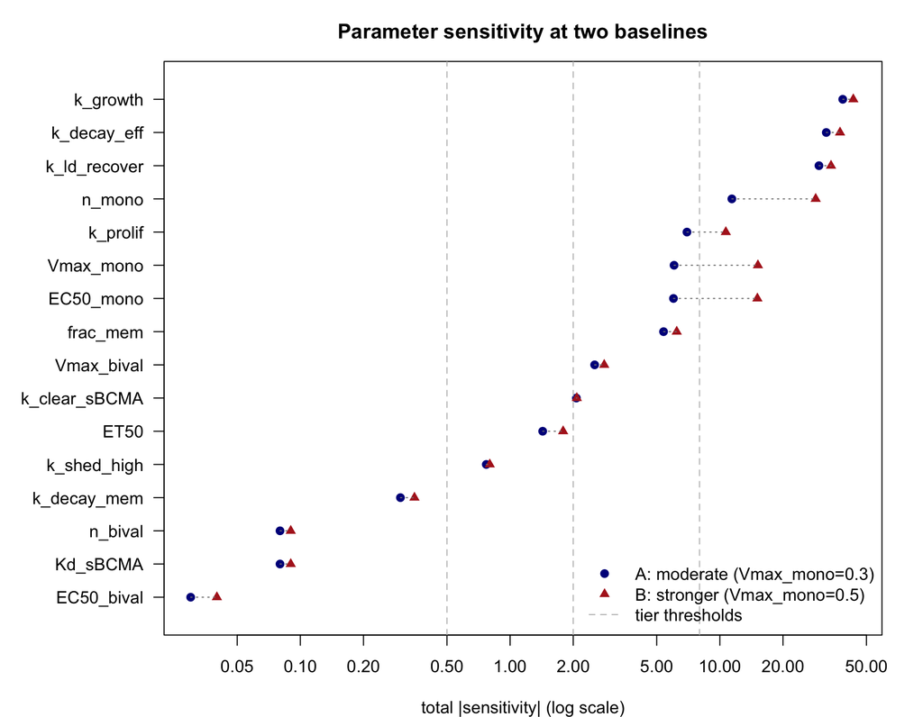

# 9 Verdict

```
## SUMMARY
```

```
## Tier stability: 13/16 parameters in same tier across A and B
```

```
## Unidentifiable pairs stable across baselines: 9 (of 9 flagged at baseline A)
```

```
##
## Parameters that shift tier:
##  parameter              tier_A                 tier_B stable
##  EC50_mono moderate (estimate) strong (BSV candidate)  FALSE
##   k_prolif moderate (estimate) strong (BSV candidate)  FALSE
##  Vmax_mono moderate (estimate) strong (BSV candidate)  FALSE
```

## 9.1 Interpretation guide

- **n_stable ≥ 14/16 and all unidentifiable pairs stable:** the v2 findings are robust. Proceed to nlmixr2 model drafting with confidence.
- **n_stable between 11 and 13:** mostly robust. Inspect the specific parameters that shifted tier — if they’re parameters that weren’t going to be free in the fit anyway (e.g., they shifted between “fix” and “weak”), the fit strategy is unaffected. If they’re tier shifts that change the estimation plan (e.g., “strong” → “weak”), handle those parameters carefully in the fit: consider estimating at multiple starting points or using a prior.
- **n_stable < 11 or key unidentifiable pairs flipping:** the local sensitivity at a single baseline is not sufficient. Before fitting, run global sensitivity (Sobol or Morris via the `sensitivity` R package) or use profile-likelihood diagnostics on a pilot fit.